# Heart disease analysis

Sanjana Gowda

2023-07-15

### Introduction

This dataset contains detailed information on the risk factors for cardiovascular disease. It includes information on age, gender, height, weight, blood pressure values, cholesterol levels, glucose levels, smoking habits and alcohol consumption of over 70 thousand individuals. Additionally it outlines if the person is active or not and if he or she has any cardiovascular diseases.

Source: https://www.kaggle.com/datasets/thedevastator/exploring-risk-factors-for-cardiovascular-diseas

The dataset consists of:

- Numeric values for age, height, weight, systolic blood pressure (ap_hi) and diastolic blood pressure (ap_lo).
- Binary values for gender, alcohol consumption (alco), smoking habits (smoke), active person (active), cardiovascular diseases (cardio). In the gender variable it’s not defined which value correspond to which gender. In the rest of the cases 0 = No and 1 = Yes.
- Levels in the cholesterol and glucose (gluc) variables. In this cases I will consider that 1 = normal, 2 = above normal, 3 = well above normal.

### Hypothesis to be tested

- The lifestyle of the people impact on the risk of having cardiovascular diseases.
- There isn’t a correlation between gender and having cardiovascular diseases
- High levels of glucose and cholesterol contributes to developing cardiovascular diseases.
- Older people have more risk to have cardiovascular diseases.
- People with higher body mass index have more risks to develop cardiovascular diseases.
- People with higher blood pressure have more risks to develop cardiovascular diseases.

## Analysis

### Loading libraries and dataset

```r
heart_data <- read.csv("C:/Users/Sanjana/Downloads/heart_data.csv")

library(tidyverse)
library(skimr)
library(ggpmisc)
library(cowplot)
library(caret)
library(stringr)
library(dplyr)
```

### Preview of the dataset

```r
head(heart_data)
```

```
##   index id   age gender height weight ap_hi ap_lo cholesterol gluc smoke alco
## 1     0  0 18393      2    168     62   110    80           1    1     0    0
## 2     1  1 20228      1    156     85   140    90           3    1     0    0
## 3     2  2 18857      1    165     64   130    70           3    1     0    0
## 4     3  3 17623      2    169     82   150   100           1    1     0    0
## 5     4  4 17474      1    156     56   100    60           1    1     0    0
## 6     5  8 21914      1    151     67   120    80           2    2     0    0
##   active cardio
## 1      1      0
## 2      1      1
## 3      0      1
## 4      1      1
## 5      0      0
## 6      0      0
```

### Complete summary of the dataset

```r
skim_without_charts(heart_data)
```

Data summary

| Name | heart_data |
| --- | --- |
| Number of rows | 70000 |
| Number of columns | 14 |
| _______________________ |  |
| Column type frequency: |  |
| numeric | 14 |
| ________________________ |  |
| Group variables | None |

**Variable type: numeric**

| skim_variable | n_missing | complete_rate | mean | sd | p0 | p25 | p50 | p75 | p100 |
| --- | --- | --- | --- | --- | --- | --- | --- | --- | --- |
| index | 0 | 1 | 34999.50 | 20207.40 | 0 | 17499.75 | 34999.5 | 52499.25 | 69999 |
| id | 0 | 1 | 49972.42 | 28851.30 | 0 | 25006.75 | 50001.5 | 74889.25 | 99999 |
| age | 0 | 1 | 19468.87 | 2467.25 | 10798 | 17664.00 | 19703.0 | 21327.00 | 23713 |
| gender | 0 | 1 | 1.35 | 0.48 | 1 | 1.00 | 1.0 | 2.00 | 2 |
| height | 0 | 1 | 164.36 | 8.21 | 55 | 159.00 | 165.0 | 170.00 | 250 |
| weight | 0 | 1 | 74.21 | 14.40 | 10 | 65.00 | 72.0 | 82.00 | 200 |
| ap_hi | 0 | 1 | 128.82 | 154.01 | -150 | 120.00 | 120.0 | 140.00 | 16020 |
| ap_lo | 0 | 1 | 96.63 | 188.47 | -70 | 80.00 | 80.0 | 90.00 | 11000 |
| cholesterol | 0 | 1 | 1.37 | 0.68 | 1 | 1.00 | 1.0 | 2.00 | 3 |
| gluc | 0 | 1 | 1.23 | 0.57 | 1 | 1.00 | 1.0 | 1.00 | 3 |
| smoke | 0 | 1 | 0.09 | 0.28 | 0 | 0.00 | 0.0 | 0.00 | 1 |
| alco | 0 | 1 | 0.05 | 0.23 | 0 | 0.00 | 0.0 | 0.00 | 1 |
| active | 0 | 1 | 0.80 | 0.40 | 0 | 1.00 | 1.0 | 1.00 | 1 |
| cardio | 0 | 1 | 0.50 | 0.50 | 0 | 0.00 | 0.0 | 1.00 | 1 |

### Looking for duplicates

```r
length(unique(heart_data$id))
```

```
## [1] 70000
```

There are 14 columns and 70000 rows, 0 NAs, and 0 duplicates in the dataset

It can be seen a lot of inconsistency in the data:

- The ap_hi and ap_lo columns have values that are biologically impossible.
- In the weight and height column there are also weird values.

In these measured variables there may be errors when recording them. So when analyzing those variables, i will remove the outliers applying the IQR method (1). In that range, the wrong data will be deleted, and the analyzed data will be large enough to be representative of the entire population.

```r
str(heart_data)
```

```
## 'data.frame':    70000 obs. of  14 variables:
##  $ index      : int  0 1 2 3 4 5 6 7 8 9 ...
##  $ id         : int  0 1 2 3 4 8 9 12 13 14 ...
##  $ age        : int  18393 20228 18857 17623 17474 21914 22113 22584 17668 19834 ...
##  $ gender     : int  2 1 1 2 1 1 1 2 1 1 ...
##  $ height     : int  168 156 165 169 156 151 157 178 158 164 ...
##  $ weight     : num  62 85 64 82 56 67 93 95 71 68 ...
##  $ ap_hi      : int  110 140 130 150 100 120 130 130 110 110 ...
##  $ ap_lo      : int  80 90 70 100 60 80 80 90 70 60 ...
##  $ cholesterol: int  1 3 3 1 1 2 3 3 1 1 ...
##  $ gluc       : int  1 1 1 1 1 2 1 3 1 1 ...
##  $ smoke      : int  0 0 0 0 0 0 0 0 0 0 ...
##  $ alco       : int  0 0 0 0 0 0 0 0 0 0 ...
##  $ active     : int  1 1 0 1 0 0 1 1 1 0 ...
##  $ cardio     : int  0 1 1 1 0 0 0 1 0 0 ...
```

### Data processing

I’ve made some processing in the data:

1. Turn age from days to years.
2. Remove outliers from the age variable since there are only four values corresponding to the age of 30, the rest are in the range of 39-65 years old.
3. Change 0, 1 code in smoke, alco, active, and cardio. E.g “Smoker”, “No smoker”.
4. Change cholesterol, gluc and gender columns to factor.
5. Calculate body mass index (BMI). Formula = weight(kg)/height(m)^2). And classificate those bmi values according to the World Health Organization classification (2):
   - <18.5 underweight (uw)
   - 18.5-24.9 normal weight (normal)
   - 25.0 - 29.9 pre-obesity (pre-ob)
   - 30.0 - 34.9 obesity class 1 (ob 1)
   - 35.0 - 39.9 obesity class 2 (ob 2)
   - ≥ 40 obesity class 3 (ob 3)
6. Calculate mean arterial pressure (MAP). Formula = (ap_hi+ap_lo*2)/3. And classificate those map values according to the American Hearth Association (2020) (3):
   - <90 Normal (normal)
   - 90 to 91.99 Elevated blood pressure (high-bp)
   - 92 to 95.99 Hypertension stage 1 (hyp1)
   - ≥ 96 Hypertension stage 2 (hyp2)
7. Selecting desired columns

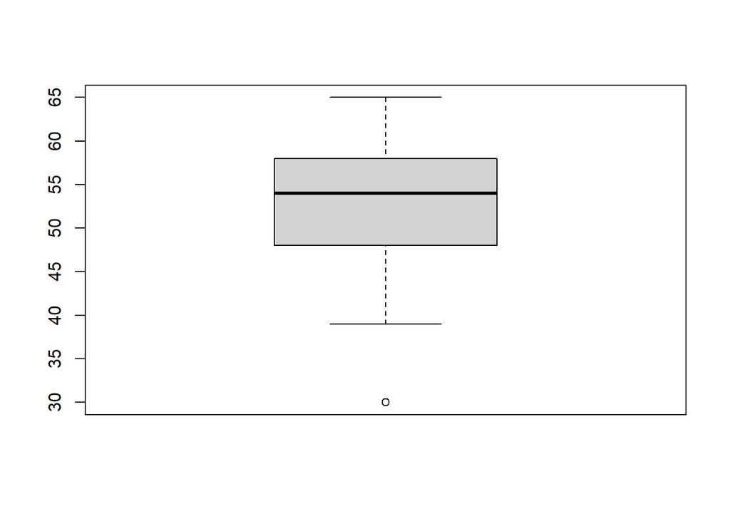

```r
#Converting the units from the age column from days to years
heart_data$age_years <- round(heart_data$age/365)
#Analyzing the range of ages from the participants
box<-boxplot(heart_data$age_years) #Here we can see that exists a clearly outlier in the age of 30. There are only 4 rows with that value, so they have to be removed.
```

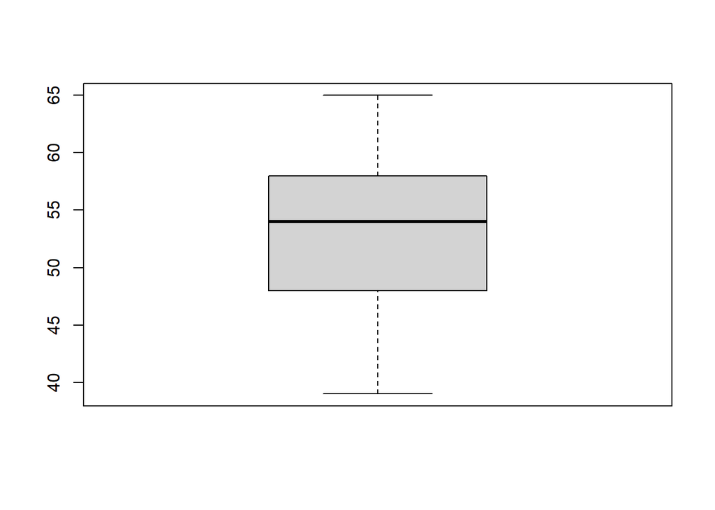

```r
heart_data<-filter(heart_data, age_years != 30)

box2<-boxplot(heart_data$age_years)
```

```r
#All adults from 39 to 65 years, with a mean of 53.34


#Changing values in columns to be more descriptive
heart_data["cardio"][heart_data["cardio"] == 0] <- 'No disease'
heart_data["cardio"][heart_data["cardio"] == 1] <- 'Disease'
heart_data["smoke"][heart_data["smoke"] == 0] <- 'No smoker'
heart_data["smoke"][heart_data["smoke"] == 1] <- 'Smoker'
heart_data["alco"][heart_data["alco"] == 0] <- 'No alco'
heart_data["alco"][heart_data["alco"] == 1] <- 'Alco'
heart_data["active"][heart_data["active"] == 0] <- 'No active'
heart_data["active"][heart_data["active"] == 1] <- 'Active'




#Changing some columns from int to factor format
heart_data$cholesterol<-as.factor(heart_data$cholesterol)
heart_data$gluc<-as.factor(heart_data$gluc)
heart_data$gender <- as.factor(heart_data$gender)




#Calculating the body mass index (bmi); Formula = weight(kg)/height(m)^2
heart_data$bmi <- heart_data$weight/(heart_data$height/100)^2

#Classifying bmi accord to the World Health Organization classification:

heart_data$bmi_class <- cut(heart_data$bmi,
                            breaks = c(-Inf, 18.49, 24.9, 29.9,
                                       34.9, 39.9, Inf),
                            labels = c("uw", "normal", "pre-ob",
                                       "ob 1", "ob 2", "ob 3"))


#Calculating the mean arterial pressure (map) ; Formula = (ap_hi+ap_lo*2)/3
heart_data$map <- (heart_data$ap_hi+heart_data$ap_lo*2)/3

#Classificating map according to the American Hearth Association (2020)


heart_data$map_class<- cut(heart_data$map,
                           breaks = c(-Inf, 89.99, 91.99, 95.99, Inf),
                           labels = c("normal", "high-bp", "hyp1", "hyp2"))


#Keeping a dataset deleting unnecesary columns
heart_data<-select(heart_data, age_years, gender, bmi, bmi_class, map,
                   map_class,gluc, cholesterol, smoke, alco, active, cardio)

# Capitalizing the first letter of each column name
heart_data <- heart_data %>%
  rename_with(~str_to_title(.))
```

```r
head(heart_data)
```

```
##   Age_years Gender      Bmi Bmi_class       Map Map_class Gluc Cholesterol
## 1        50      2 21.96712    normal  90.00000   high-bp    1           1
## 2        55      1 34.92768      ob 2 106.66667      hyp2    1           3
## 3        52      1 23.50781    normal  90.00000   high-bp    1           3
## 4        48      2 28.71048    pre-ob 116.66667      hyp2    1           1
## 5        48      1 23.01118    normal  73.33333    normal    1           1
## 6        60      1 29.38468    pre-ob  93.33333      hyp1    2           2
##       Smoke    Alco    Active     Cardio
## 1 No smoker No alco    Active No disease
## 2 No smoker No alco    Active    Disease
## 3 No smoker No alco No active    Disease
## 4 No smoker No alco    Active    Disease
## 5 No smoker No alco No active No disease
## 6 No smoker No alco No active No disease
```

```r
# Identify integer variables
integer_vars <- sapply(heart_data, is.integer)

# Convert integer variables to numeric
heart_data[integer_vars] <- lapply(heart_data[integer_vars], as.numeric)

str(heart_data)
```

```
## 'data.frame':    69996 obs. of  12 variables:
##  $ Age_years  : num  50 55 52 48 48 60 61 62 48 54 ...
##  $ Gender     : Factor w/ 2 levels "1","2": 2 1 1 2 1 1 1 2 1 1 ...
##  $ Bmi        : num  22 34.9 23.5 28.7 23 ...
##  $ Bmi_class  : Factor w/ 6 levels "uw","normal",..: 2 5 2 3 2 3 5 4 3 3 ...
##  $ Map        : num  90 106.7 90 116.7 73.3 ...
##  $ Map_class  : Factor w/ 4 levels "normal","high-bp",..: 2 4 2 4 1 3 4 4 1 1 ...
##  $ Gluc       : Factor w/ 3 levels "1","2","3": 1 1 1 1 1 2 1 3 1 1 ...
##  $ Cholesterol: Factor w/ 3 levels "1","2","3": 1 3 3 1 1 2 3 3 1 1 ...
##  $ Smoke      : chr  "No smoker" "No smoker" "No smoker" "No smoker" ...
##  $ Alco       : chr  "No alco" "No alco" "No alco" "No alco" ...
##  $ Active     : chr  "Active" "Active" "No active" "Active" ...
##  $ Cardio     : chr  "No disease" "Disease" "Disease" "Disease" ...
```

So it will be analyzed the risk factors for developing cardiovascular diseases in adult people from 39 to 65 years old.

## Analysis

### Lifestyle analisis: smoking, drinking and activity.

First I’m gonna analyze the relationship of lifestyles (smoking, drinking alcohol and being active) and the development of cardiovascular diseases.

- In each case a Chisquare test was made to determine if there are statistical differences between conditions (e.g smoking or not smoking).
- In all cases H0 = no differences between conditions; H1 = differences between conditions.

```r
 #Function to make a relative frequencies table
freq.table <- function (x, y, z){substitute(x %>%
                                              group_by(y, z) %>%
                                              summarise(n = n ()) %>%
                                              mutate(freq = n / sum (n)))%>%
    eval}
```

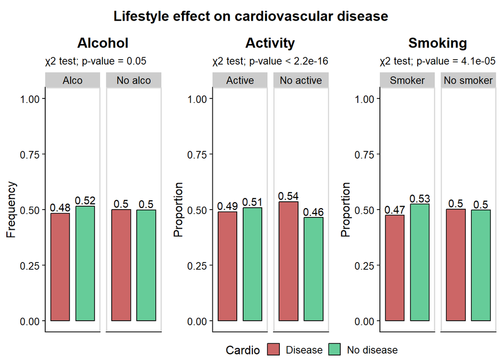

```r
#Alcohol drinking and cardiovascular disease

alco <- freq.table(heart_data, Alco, Cardio)

alcochi<-chisq.test(heart_data$Cardio, heart_data$Alco, correct=FALSE)

alco.plot<-  ggplot(data = alco,  aes(x = Cardio, y = freq, fill = Cardio)) +
  geom_bar(stat='identity',
           colour = 'black',
           width=.75)+
  geom_text(aes(label=round(freq,2)),
            position=position_dodge(width=0.9),
            vjust=-0.25)+
  ylim (0, 1)+
  facet_grid(~Alco)+ #Split plot by lifestyle
  scale_fill_manual(values=c( "#CC6666", "#66CC99"))+
  theme_half_open(12)+
  panel_border()+
  ggtitle("Alcohol")+ #Add title
  theme(plot.title = element_text(hjust = 0.5), #Center the title
        axis.title.x=element_blank(), #Remove X label
        axis.text.x=element_blank(),
        axis.ticks.x=element_blank())+
  labs(y = "Frequency",
    subtitle = "χ2 test; p-value = 0.05") #subtitle with p-value




#Activity of the people and cardiovascular disease

active<-freq.table(heart_data, Active, Cardio)

activechi<-chisq.test(heart_data$Cardio, heart_data$Active, correct=FALSE)

active.plot<-ggplot(data = active,  aes(x = Cardio, y = freq, fill = Cardio)) +
  geom_bar(stat='identity', colour = 'black',  width=0.75)+
  geom_text(aes(label=round(freq,2)), position=position_dodge(width=0.9), vjust=-0.25)+
  ylim (0, 1)+
  facet_grid(~Active)+ #Split plot by lifestyle
  scale_fill_manual(values=c("#CC6666", "#66CC99"))+
  theme_half_open(12)+
  panel_border()+
  ggtitle("Activity")+ #Add title
  theme(plot.title = element_text(hjust = 0.5), #Center the title
              axis.title.x=element_blank(), #Remove X label
              axis.text.x=element_blank(),
              axis.ticks.x=element_blank())+
  labs(y = "Proportion",
       subtitle = "χ2 test; p-value < 2.2e-16") #subtitle with p-value



#Now if smokes contributes to the cardiovascular disease
smoke <- freq.table(heart_data, Smoke, Cardio)

smokechi<-chisq.test(heart_data$Cardio, heart_data$Smoke, correct=FALSE)

smoke.plot <- ggplot(data = smoke, aes(x = Cardio, y = freq, fill = Cardio)) +
  geom_bar(stat='identity', colour = 'black',  width=0.75)+
  geom_text(aes(label=round(freq,2)), position=position_dodge(width=0.9), vjust=-0.25)+
  ylim (0, 1)+
  facet_grid(~factor(Smoke, levels=c('Smoker', 'No smoker')))+ #Split plot by lifestyle
  scale_fill_manual(values=c("#CC6666", "#66CC99"))+
  theme_half_open(12)+
  panel_border()+
  ggtitle("Smoking")+ #Add title
  theme(plot.title = element_text(hjust = 0.5), #Center the title
              axis.title.x=element_blank(), #Remove X label
              axis.text.x=element_blank(),
              axis.ticks.x=element_blank())+
  labs( y = "Proportion",
       subtitle = "χ2 test; p-value = 4.1e-05")#subtitle with p-value


#putting all three plots in one


lifestyle.plot<-plot_grid(alco.plot+ theme(legend.position="none"),
                          active.plot+ theme(legend.position="none"),
                          smoke.plot+theme(legend.position="none"),
                          ncol=3)

title <- ggdraw() + draw_label("Lifestyle effect on cardiovascular disease",
                               fontface='bold') #Creating title

lifestyle.plot<- plot_grid(title,
                           lifestyle.plot,
                           ncol = 1,
                           rel_heights=c(0.1, 1))


legend <- get_legend(smoke.plot +theme(legend.position = c(.45,.5),
                                       legend.direction="horizontal")) #Creating legend


lifestyle.plot<-plot_grid(lifestyle.plot,
                           legend,
                           ncol=1,
                           rel_heights = c(1, .05))

lifestyle.plot
```

From the previous graphs it can be made some deductions:

- The lifestyle of the adult people between 39 and 65 years, contributes to developing or not a cardiovascular disease.
- Being an active person it’s fundamental to minimize the risk of developing a cardiovascular disease.
- In the people who drink alcohol, there aren’t significant differences.
- Analyzing the smoking people, statically speaking, there are significant differences (p-value << 0.05), and in the group who smoke there are less people with cardiovascular disease. But this is erroneous and it’s related to a small sample size. A lot of bibliography says the opposite (4).
- More detail in the information is needed to be more precisely in the impact of lifestyles in the development of a cardiovascular disease, e.g: the amount of alcohol drinking per day, amount of cigarettes per day, etc.

Next I’m gonna analyze if there is a relationship between the personal characteristics of the people (age, gender, cholesterol, gluc, map ,bmi) and cardiovascular diseases

### Analyzing gender

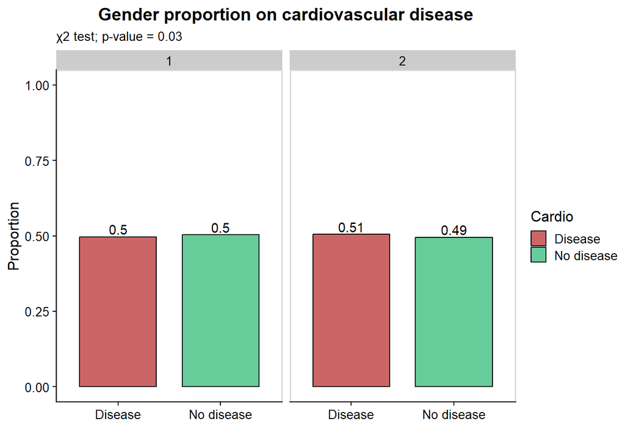

```r
gender <- freq.table(heart_data, Gender, Cardio)

genderchi<-chisq.test(heart_data$Gender, heart_data$Cardio)

gender.plot<-ggplot(gender, aes(x = Cardio, y = freq,  fill = Cardio))+
  geom_bar(stat='identity', colour = 'black',  width=0.75)+
  ylim (0, 1)+
  geom_text(aes(label=round(freq,2)), position=position_dodge(width=0.9), vjust=-0.25)+
  facet_grid(~Gender)+ #dividing by gender
  scale_fill_manual(values=c("#CC6666", "#66CC99"))+
  theme_half_open(12)+
  panel_border()+
  ggtitle("Gender proportion on cardiovascular disease")+ #Add title
  theme(plot.title = element_text(hjust = 0.5))+ #Center the title
    labs(x = "", y = "Proportion",
          subtitle = "χ2 test; p-value = 0.03") #Subtitle with p-value


gender.plot
```

### Now analyzing cholesterol and glucose levels

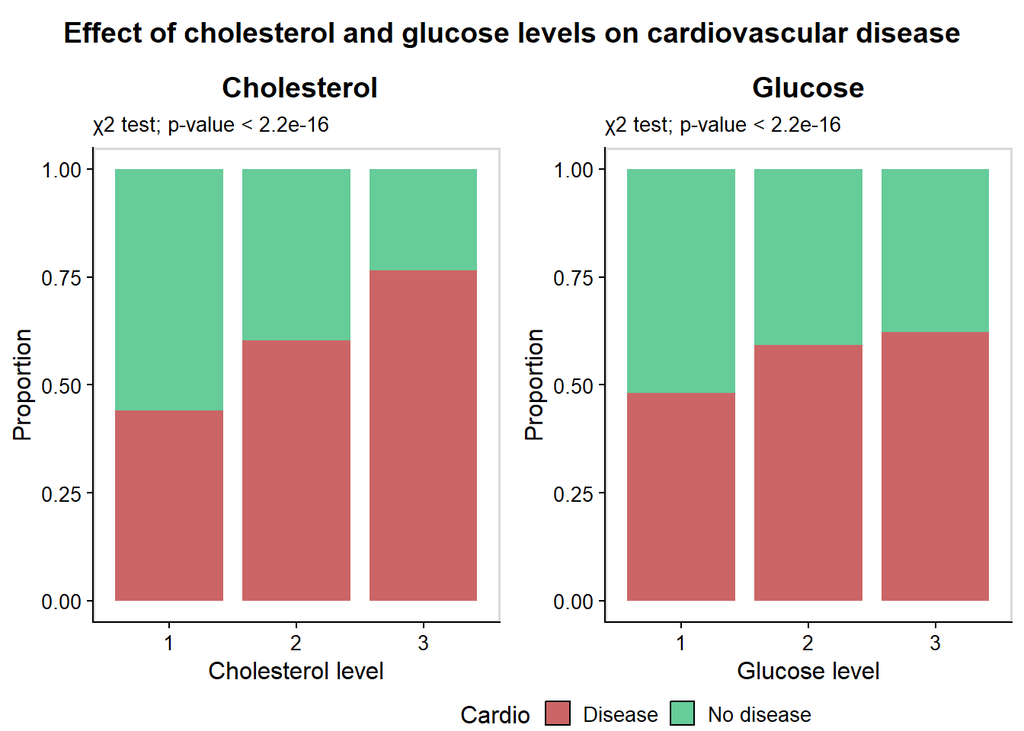

```r
#Cholesterol levels and cardiovascular disease

cholesterol<-freq.table(heart_data, Cholesterol, Cardio)


cholchi<-chisq.test(heart_data$Cholesterol, heart_data$Cardio, correct = FALSE)

cholesterol.plot<-ggplot(cholesterol, aes(x = Cholesterol, y = freq,  fill = Cardio))+
  geom_bar(stat = 'identity', width=0.85, position = position_fill (reverse = TRUE))+
  scale_fill_manual(values=c("#CC6666", "#66CC99"))+
  theme_half_open(12)+
  panel_border()+
  ggtitle(" Cholesterol")+ #Add title
  theme(plot.title = element_text(hjust = 0.5))+ #Center the title
  labs(x = "Cholesterol level", y = "Proportion",
       subtitle = "χ2 test; p-value < 2.2e-16")


#Checking the same with the gluc

gluc<-freq.table(heart_data, Gluc, Cardio)

glucchi<-chisq.test(heart_data$Gluc, heart_data$Cardio, correct = FALSE)

gluc.plot<-ggplot(gluc, aes(x = Gluc, y = freq,  fill = Cardio))+
  geom_bar(stat = 'identity', width=0.85, position = position_fill (reverse = TRUE))+
  scale_fill_manual(values=c("#CC6666", "#66CC99"))+
  theme_half_open(12)+
  panel_border()+
  ggtitle("Glucose")+ #Add title
  theme(plot.title = element_text(hjust = 0.5))+ #Center the title
  labs(x = "Glucose level", y = "Proportion",
       subtitle = "χ2 test; p-value < 2.2e-16")



#Putting the two plots together

gluc_and_chol<-plot_grid(cholesterol.plot+ theme(legend.position="none"),
                         gluc.plot+ theme(legend.position="none"),
                         ncol=2,
                         rel_heights = c(1, .1))

title_chol <- ggdraw() + draw_label("Effect of cholesterol and glucose levels on cardiovascular disease", fontface='bold')

gluc_and_chol<- plot_grid(title_chol,
                           gluc_and_chol,
                           ncol = 1,
                           rel_heights=c(0.1, 1))

gluc_and_chol<-plot_grid(gluc_and_chol,
                         legend,
                         ncol=1,
                         rel_heights = c(1, .05))

gluc_and_chol
```

Higher levels of glucose and cholesterol are associated with higher proportion of people with cardiovascular diseases:

- Having “well above normal” levels of cholesterol it’s highly correlated with a high proportion of people with cardiovascular diseases (77%).
- Having “above normal” and “well above normal” levels of glucose have similar proportions of people with cardiovascular diseases (59% and 62% respectively).

### Relationship between age and cardiovascular diseases

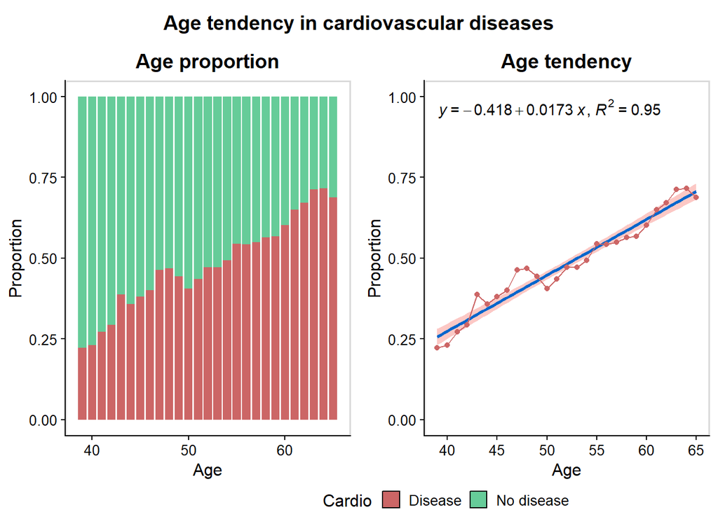

```r
age <- freq.table(heart_data, Age_years, Cardio)
age.plot<-ggplot(age, aes(x = Age_years, y = freq,  fill = Cardio))+
  geom_bar(stat = 'identity', width=0.85, position = position_fill (reverse = TRUE))+
  scale_fill_manual(values=c("#CC6666", "#66CC99"))+
  theme_half_open(12)+
  panel_border()+
  ggtitle("Age proportion")+ #Add title
  theme(plot.title = element_text(hjust = 0.5))+ #Center the title
  labs(x = "Age", y = "Proportion" )



age.1<-subset(age, Cardio == "Disease") #Focusing only in the cases which have cardiovascular disease

corage<-cor(age.1$Age_years,age.1$freq) #exists a correlation of 0.97

age.tendency.plot<-ggplot(data = age.1, aes(x = Age_years, y = freq, fill = Cardio)) +
  stat_poly_line(color="#0066CC") +#adding tendency line
  stat_poly_eq(aes(label = paste(after_stat(eq.label),
                                 after_stat(rr.label),
                                 sep = "*\", \"*")))+ #adding equation and r2
  geom_point(color="#CC6666")+
  geom_line(color="#CC6666")+
  ylim(0,1)+
  theme_half_open(12)+
  panel_border()+
  ggtitle("Age tendency")+ #Add title
  theme(plot.title = element_text(hjust = 0.5))+ #Center the title
  labs(x = "Age", y = "Proportion" )


#putting the two plots together

ages.plot<-plot_grid(age.plot+ theme(legend.position="none"),
                         age.tendency.plot+ theme(legend.position="none"),
                         ncol=2,
                         rel_heights = c(1, .1))

title_ages <- ggdraw() + draw_label("Age tendency in cardiovascular diseases",
                                    fontface='bold')

ages.plot<- plot_grid(title_ages,
                           ages.plot,
                           ncol = 1,
                           rel_heights=c(0.1, 1))

ages.plot<-plot_grid(ages.plot,
                         legend,
                         ncol=1,
                         rel_heights = c(1, .05))

ages.plot
```

As can be seen in this graphs, there is a positive linear correlation between age and proportion of people with cardiovascular diseases. In older people, the proportion of people with cardiovascular disease is much higher than in the youngest: in the range from 60 to 65 years, the proportion of people with cardiovascular diseases is around 70%, meanwhile in the youngest group from 39 to 45 years old the proportion range of people with cardiovascular diseases is between 22 and 40%.

### Now working with the BMI variable

```r
#Defining function for delete outliers with IQRmethod
IQRmethod <- function(x,y){quartiles <- quantile(y, probs=c(.25, .75),
                                                 na.rm = FALSE)
no_outlier <- subset(x, y > quartiles[1] - 1.5*IQR(y) & y < quartiles[2] + 1.5*IQR(y))
return(no_outlier)}
```

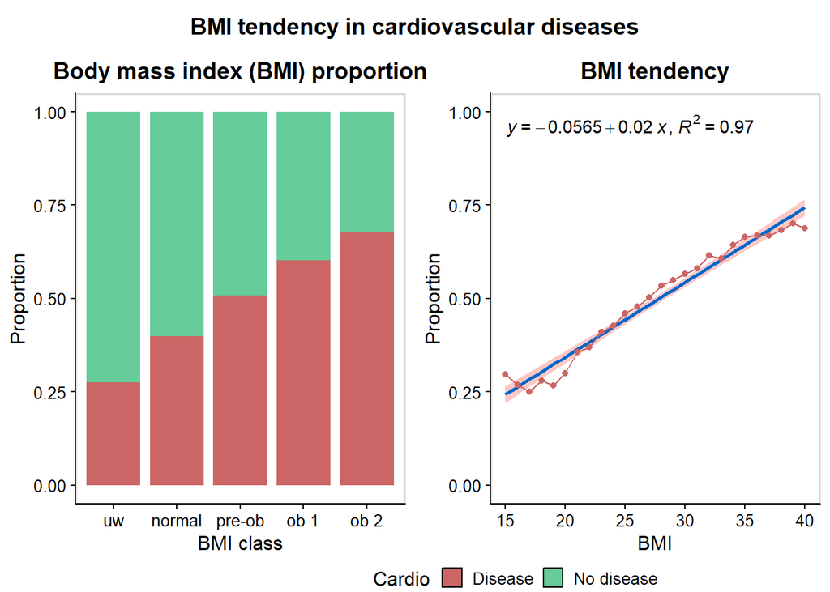

```r
#Removing outliers
bmi_cutt <- IQRmethod(heart_data, heart_data$Bmi)

#Building freq table without outliers
bmi<-freq.table(bmi_cutt, Bmi_class, Cardio)


bmi.plot<-ggplot(bmi, aes(x = Bmi_class, y = freq, fill = Cardio))+
  geom_bar(stat = 'identity', width=0.85, position = position_fill (reverse = TRUE))+
  scale_fill_manual(values=c("#CC6666", "#66CC99"))+
  theme_half_open(12)+
  panel_border()+
  ggtitle("Body mass index (BMI) proportion")+ #Add title
  theme(plot.title = element_text(hjust = 0.5))+ #Center the title
  labs(x = "BMI class", y = "Proportion" )

#Now determining the correlation between BMI and the proportion of people with cardiovascular disease.

#Obtaining round values
bmi.round<-freq.table(bmi_cutt, round(Bmi), Cardio)

bmi.1<-subset(bmi.round, Cardio == "Disease") #Focusing only in the cases which have cardiovascular disease

corbmi<-cor(bmi.1$`round(Bmi)`,bmi.1$freq) #exists a correlation of 0.98

bmi.tendency.plot<-ggplot(data = bmi.1, aes(x = `round(Bmi)`, y = freq, fill = Cardio)) +
  stat_poly_line(color="#0066CC") + #adding tendency line
  stat_poly_eq(aes(label = paste(after_stat(eq.label), #equation
                                 after_stat(rr.label), #r2
                                 sep = "*\", \"*")))+
  geom_point(color="#CC6666")+
  geom_line(color="#CC6666")+
  ylim(0,1)+
  theme_half_open(12)+
  panel_border()+
  ggtitle("BMI tendency")+ #Add title
  theme(plot.title = element_text(hjust = 0.5))+ #Center the title
  labs(x = "BMI", y = "Proportion" )


#Putting plots together

bmi.plot1<-plot_grid(bmi.plot+ theme(legend.position="none"),
                         bmi.tendency.plot+ theme(legend.position="none"),
                         ncol=2,
                         rel_heights = c(1, .1))

title_bmi <- ggdraw() + draw_label("BMI tendency in cardiovascular diseases", fontface='bold')

bmi.plot1<- plot_grid(title_bmi,
                           bmi.plot1,
                           ncol = 1,
                           rel_heights=c(0.1, 1))

bmi.plot1<-plot_grid(bmi.plot1,
                         legend,
                         ncol=1,
                         rel_heights = c(1, .05))

bmi.plot1
```

Here it can be seen a positive linear correlation. Higher BMI it’s correlated with higher proportion of people with cardiovascular diseases.

### Analyzing MAP

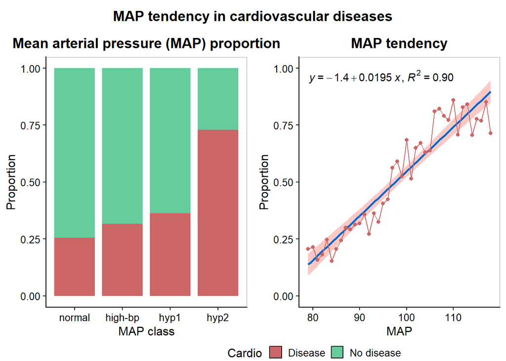

```r
#Doing the same but with the MAP
map_cutt<-IQRmethod(heart_data, heart_data$Map)


map<-freq.table(map_cutt, Map_class, Cardio)

map.plot<-ggplot(map, aes(x = Map_class, y = freq, fill = Cardio))+
  geom_bar(stat = 'identity', width=0.85, position = position_fill (reverse = TRUE))+
  scale_fill_manual(values=c("#CC6666", "#66CC99"))+
  theme_half_open(12)+
  panel_border()+
  ggtitle("Mean arterial pressure (MAP) proportion")+ #Add title
  theme(plot.title = element_text(hjust = 0.5))+ #Center the title
  labs(x = "MAP class", y = "Proportion" )


map.round<-freq.table(map_cutt, round(Map), Cardio)

map.1<-subset(map.round, Cardio == "Disease") #Focusing only in the cases which have cardiovascular disease

cormap<-cor(map.1$`round(Map)`,map.1$freq) #exists a correlation of 0.95

map.tendency.plot<-ggplot(data = map.1, aes(x = `round(Map)`, y = freq, fill = Cardio)) +
  stat_poly_line(color="#0066CC") + #tendency line
  stat_poly_eq(aes(label = paste(after_stat(eq.label), #equation
                                 after_stat(rr.label), #r2
                                 sep = "*\", \"*")))+
  geom_point(color="#CC6666")+
  geom_line(color="#CC6666")+
  ylim(0,1)+
  theme_half_open(12)+
  panel_border()+
  ggtitle("MAP tendency")+
  theme(plot.title = element_text(hjust = 0.5))+
  labs(x = "MAP", y = "Proportion" )



map.plot1<-plot_grid(map.plot+ theme(legend.position="none"),
                         map.tendency.plot+ theme(legend.position="none"),
                         ncol=2,
                         rel_heights = c(1, .1))

title_map <- ggdraw() + draw_label("MAP tendency in cardiovascular diseases",
                                   fontface='bold')

map.plot1<- plot_grid(title_map,
                           map.plot1,
                           ncol = 1,
                           rel_heights=c(0.1, 1))

map.plot1<-plot_grid(map.plot1,
                         legend,
                         ncol=1,
                         rel_heights = c(1, .05))

map.plot1
```

Viewing the mean arterial pressure, it also can be seen a positive linear correlation. In the hypertension 2 group is where the proportion of people with cardiovascular diseases is really higher (73%).

So these three measurable variables (age, BMI and MAP) can help to determine the probability of getting a cardiovascular disease.

## Logistic regression model

Now I will see if a logistic regression model with that 3 measurable variables can help to predict the risk of getting cardiovascular disease.

```r
#removing the outliers for both bmi, map
no.outlier <- IQRmethod(heart_data, heart_data$Map)
no.outlier <- IQRmethod(no.outlier, no.outlier$Bmi)

#Creating boolean column
no.outlier$Boolean <- no.outlier$Cardio=="Disease"


# Split the data into training and test set
set.seed(123)
training.samples <- no.outlier$Boolean %>%
  createDataPartition(p = 0.8, list = FALSE)
train.data  <- no.outlier[training.samples, ]
test.data <- no.outlier[-training.samples, ]

 #Analyzing the glm model
glmMod <- glm(Boolean ~ Bmi + Map + Age_years,
              data = train.data,
              family = "binomial")

summary(glmMod) #Here it can be seen that all variables are significant when explaining the probability of getting a heart disease.
```

```
##
## Call:
## glm(formula = Boolean ~ Bmi + Map + Age_years, family = "binomial",
##     data = train.data)
##
## Coefficients:
##               Estimate Std. Error z value Pr(>|z|)
## (Intercept) -14.106442   0.158937  -88.75   <2e-16 ***
## Bmi           0.039556   0.002386   16.58   <2e-16 ***
## Map           0.102305   0.001389   73.67   <2e-16 ***
## Age_years     0.059249   0.001553   38.16   <2e-16 ***
## ---
## Signif. codes:  0 '***' 0.001 '**' 0.01 '*' 0.05 '.' 0.1 ' ' 1
##
## (Dispersion parameter for binomial family taken to be 1)
##
##     Null deviance: 68522  on 49460  degrees of freedom
## Residual deviance: 57938  on 49457  degrees of freedom
## AIC: 57946
##
## Number of Fisher Scoring iterations: 3
```

The model adjusts really well. All variables are significant.

### Now testing the model accuracy

```r
# Make predictions in the test data
probabilities <- glmMod %>% predict(test.data, type = "response")
predicted.classes <- ifelse(probabilities > 0.5, "TRUE", "FALSE")

# Model accuracy
mean(predicted.classes == test.data$Boolean)
```

```
## [1] 0.7041411
```

```r
#Model accuracy ~70%
```

### Plotting the accuracy of the model

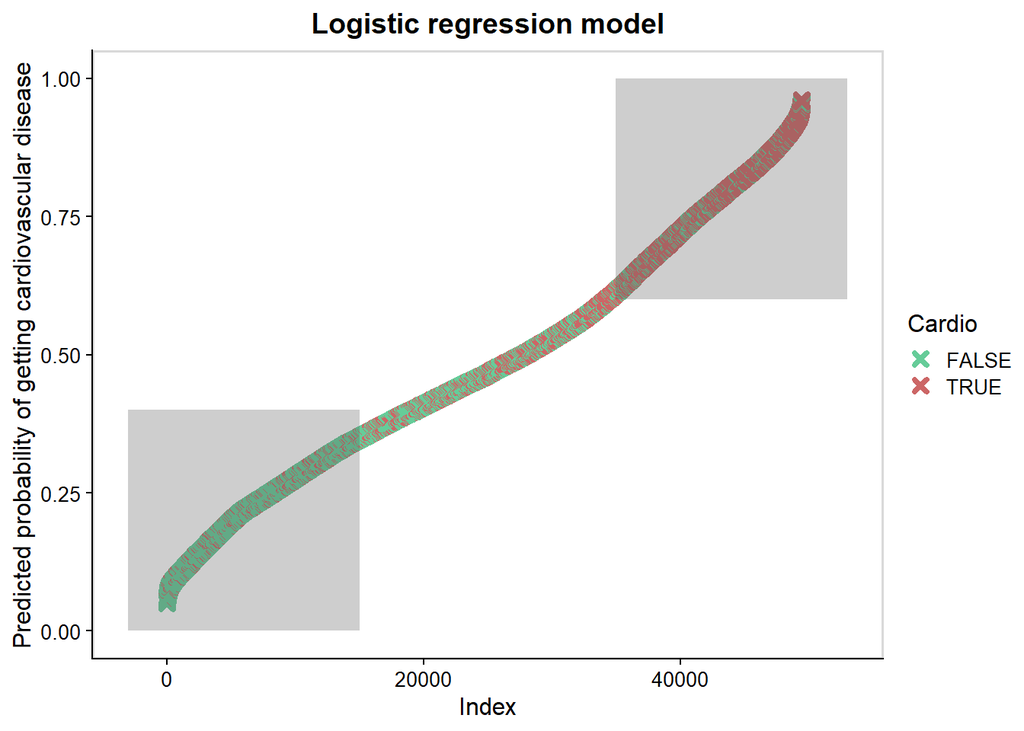

```r
#Plot the accuracy of the model

predicted.data <- data.frame(
  probability.of.cd = glmMod$fitted.values,
  Cardio=train.data$Boolean)

predicted.data <- predicted.data[
  order(predicted.data$probability.of.cd, decreasing=FALSE),]

predicted.data$rank <- 1:nrow(predicted.data)


# plot the predicted probabilities for each individual of having heart diseases and color by whether or not they actually had heart disease

predicted.plot<-ggplot(data=predicted.data, aes(x=rank, y=probability.of.cd)) +
  geom_point(aes(color=Cardio), alpha=1, shape=4, stroke=2) +
  scale_color_manual(values = c("FALSE" = "#66CC99", "TRUE" = "#CC6666"))+
  theme_half_open(12)+
  panel_border()+
  annotate("rect", xmin = 35000, xmax = 53000, ymin = 0.6, ymax = 1,
           alpha = .3)+
  annotate("rect", xmin = -3000, xmax = 15000, ymin = 0, ymax = 0.4,
           alpha = .3)+
  ggtitle("Logistic regression model")+ #Add title
  theme(plot.title = element_text(hjust = 0.5))+ #Center the title
  xlab("Index") +
  ylab("Predicted probability of getting cardiovascular disease")

predicted.plot
```

In the lowest gray area, most of the people don’t have heart disease, and in the upper gray area most of the people have cardiovascular disease. So here it’s represented the 70% of accuracy of the model

### References

- 1: https://online.stat.psu.edu/stat200/lesson/3/3.2
- 2: https://www.who.int/europe/news-room/fact-sheets/item/a-healthy-lifestyle---who-recommendations
- 3: https://www.ahajournals.org/doi/10.1161/HYPERTENSIONAHA.120.14929
- 4: https://www.hopkinsmedicine.org/health/conditions-and-diseases/smoking-and-cardiovascular-disease
- 5: https://rpubs.com/GehadGad/854190